# Assignment 2

Haoran LEI (20135212)

2019 Feb 28

## 5.1 Simulate data

1. Set the parameter variables.

```r
library(empiricalio)
library(tidyverse)
library(np)
library(latex2exp)


beta_0    <-  1
beta_l    <-  0.2
beta_k    <-    0.7
alpha     <-    0.7
sigma_eta <-    0.2
sigma_nu  <-    0.5
sigma_w   <-    0.1
delta     <-    0.05
```

2. Write the function `log_production(l, k, omega, eta, beta_0, beta_l, beta_k)`.

```r
log_production <- function(l, k, omega, eta, beta_0, beta_l, beta_k)
{
beta_0 + beta_l * l + beta_k * k + omega + eta
}
```

3. Derive the optimal log labor. Write the function to return the optimal log labor and name it `log_labor_choice(k, wage, omega, beta_0, beta_l, beta_k, sigma_eta)`.

Firm $j$ in time $t$ solves:
$$\max_{l_{jt}} \mathbb{E} \text{ exp}(\beta_0 + \beta_l l_{jt} + \beta_k k_{jt} + ω_{jt} + η_{jt}) - w_t \text{exp}(l_{jt})$$
Note that $\mathbb{E} \text{exp} (η_{jt}) =\text{exp}(\sigma_\eta^2/2)$. The objective function is reduced to
$$\text{ exp}(\sigma_\eta^2/2 + \beta_0 + \beta_k k_{jt} + η_{jt}) \text{ exp}(\beta_l l_{jt}) - w_t \text{exp}(l_{jt}).$$

FOC yields
$$l_{jt}^* = \frac{1}{1-\beta_l} (\beta_0 + \beta_k k_{jt} + \omega_{jt} + \sigma_\eta^2/2 + \log(\frac{\beta_l}{w_t}) )$$

```r
log_labor_choice <- function(k, wage, omega, beta_0, beta_l, beta_k, sigma_eta)
{
  (beta_0 + beta_k * k +  omega + (sigma_eta^2)/2  + log(beta_l / wage) ) / (1 - beta_l)
}
```

4. Modify the previous function by including $ι_{jt}$ as an additional input and name it `log_labor_choice_error(k, wage, omega, beta_0, beta_l, beta_k, iota, sigma_eta)`.

The new log labor choice function is

$$l_{jt}^* = \frac{1}{1-\beta_l} (\beta_0 + \beta_k k_{jt} + (\omega_{jt} + ι_{jt}) + \sigma_\eta^2/2 + \log(\frac{\beta_l}{w_t}) )$$

```r
log_labor_choice_error <- function(k, wage, omega, beta_0, beta_l, beta_k, iota, sigma_eta)
{
  (beta_0 + beta_k * k +  (omega + iota) + (sigma_eta^2)/2  + log(beta_l / wage) ) / (1 - beta_l)
}
```

## 6 Draw $k_{j1}$ from i.i.d. $N(1,0.5)$. Draw $ω_{j1}$ from its stationary distribution. Set wage at 0.5.

The stationary distribution of $ω_{j1}$ is $N(0,\sigma_ω)$ with
$$\sigma_ω = \sqrt{\frac{1}{1- \alpha^2}} \sigma_\nu .$$

```r
N <- 1000
j <- 1:N
t <- rep(1,N)

set.seed(1)
#Draw log_capital at t=0
k <- rnorm(N, mean = 1, sd = 0.5)

#Define sd of omega
sigma_omega <- sqrt(1/( 1- alpha ^ 2)) * sigma_nu

#Draw omega at t=1
omega <- rnorm(N, mean = 0, sd = sigma_omega)

# Set wage at 0.5
wage <- 0.5

library(tibble)
tibble(j ,t, k, omega, wage)
```

```
## # A tibble: 1,000 x 5
##        j     t     k   omega  wage
##    <int> <dbl> <dbl>   <dbl> <dbl>
##  1     1     1 0.687  0.795    0.5
##  2     2     1 1.09   0.779    0.5
##  3     3     1 0.582 -0.610    0.5
##  4     4     1 1.80   0.148    0.5
##  5     5     1 1.16   0.0486   0.5
##  6     6     1 0.590 -1.16     0.5
##  7     7     1 1.24   0.568    0.5
##  8     8     1 1.37  -1.34     0.5
##  9     9     1 1.29  -0.873    0.5
## 10    10     1 0.847  0.699    0.5
## # ... with 990 more rows
```

7 Draw optimization error $ι_{ij}$ from i.i.d. $N(0,0.05)$. Compute the labor and investment choice of period 1. For labor choice, compute both types of labor choices.

```r
iota <- rnorm(N, 0, 0.05)
gamma <- 0.1

library(empiricalio)
l <- log_labor_choice(k, wage, omega, beta_0, beta_l, beta_k, sigma_eta)

l_error <- log_labor_choice_error(k, wage, omega, beta_0, beta_l, beta_k, iota, sigma_eta)

I <- investment_choice(k, omega, delta, gamma)

tibble(j ,t, k, omega, wage, iota, l, l_error, I)
```

```
## # A tibble: 1,000 x 9
##        j     t     k   omega  wage     iota      l l_error       I
##    <int> <dbl> <dbl>   <dbl> <dbl>    <dbl>  <dbl>   <dbl>   <dbl>
##  1     1     1 0.687  0.795    0.5 -0.0443   1.72   1.67    0.257
##  2     2     1 1.09   0.779    0.5 -0.0961   2.06   1.94    0.381
##  3     3     1 0.582 -0.610    0.5  0.0810  -0.123 -0.0218 -0.0196
##  4     4     1 1.80   0.148    0.5  0.0260   1.89   1.92    0.391
##  5     5     1 1.16   0.0486   0.5 -0.00279  1.21   1.21    0.176
##  6     6     1 0.590 -1.16     0.5  0.0348  -0.809 -0.766  -0.120
##  7     7     1 1.24   0.568    0.5  0.00268  1.93   1.93    0.370
##  8     8     1 1.37  -1.34     0.5 -0.0655  -0.346 -0.428  -0.330
##  9     9     1 1.29  -0.873    0.5 -0.106    0.165  0.0327 -0.135
## 10    10     1 0.847  0.699    0.5 -0.0104   1.74   1.73    0.280
## # ... with 990 more rows
```

8. Draw ex post shock. Compute the output according to the production function for both labor without optimization error and with optimization error. Name the output without optimization error `y` and the one with optimization error `y_error`.

```r
# Set ex post shock
eta <- rnorm(N, 0, sigma_eta)

y <- log_production(l, k, omega, eta, beta_0, beta_l, beta_k)

y_error <- log_production(l_error, k, omega, eta, beta_0, beta_l, beta_k)

tibble(j ,t, k, omega, wage, iota, l, l_error, I, eta, y, y_error)
```

```
## # A tibble: 1,000 x 12
##        j     t     k   omega  wage     iota      l l_error       I     eta
##    <int> <dbl> <dbl>   <dbl> <dbl>    <dbl>  <dbl>   <dbl>   <dbl>   <dbl>
##  1     1     1 0.687  0.795    0.5 -0.0443   1.72   1.67    0.257   0.148
##  2     2     1 1.09   0.779    0.5 -0.0961   2.06   1.94    0.381   0.0773
##  3     3     1 0.582 -0.610    0.5  0.0810  -0.123 -0.0218 -0.0196  0.259
##  4     4     1 1.80   0.148    0.5  0.0260   1.89   1.92    0.391  -0.161
##  5     5     1 1.16   0.0486   0.5 -0.00279  1.21   1.21    0.176  -0.321
##  6     6     1 0.590 -1.16     0.5  0.0348  -0.809 -0.766  -0.120   0.187
##  7     7     1 1.24   0.568    0.5  0.00268  1.93   1.93    0.370   0.361
##  8     8     1 1.37  -1.34     0.5 -0.0655  -0.346 -0.428  -0.330  -0.0113
##  9     9     1 1.29  -0.873    0.5 -0.106    0.165  0.0327 -0.135   0.377
## 10    10     1 0.847  0.699    0.5 -0.0104   1.74   1.73    0.280   0.316
## # ... with 990 more rows, and 2 more variables: y <dbl>, y_error <dbl>
```

9. Repeat this procedure for $t=1,...,10$, and name the resulting data frame `df_T`.

```r
# Sorry for using for loop...
# Luckily it only takes seconds to finish.


# Set the number of time periods
T = 10

# Set the initial state variables
omega_temp <- omega
k_temp <- k
I_temp <- I

# draw nu at t=1
nu <- rnorm(N, 0, sigma_nu)

for (val in 2:T){
  # compute new state variables
  k_new <- log_capital_evolution(delta, k_temp, I_temp)

  nu_new <- rnorm(N, 0, sigma_nu)
  omega_new <- omega_evolution(alpha, omega_temp, nu_new)

  iota_new <- rnorm(N, 0, 0.05)

  eta_new <- rnorm(N, 0, sigma_eta)


  # store new state variables
  k <- c(k, k_new)
  nu <- c(nu, nu_new)
  omega <- c(omega, omega_new)
  iota <- c(iota, iota_new)
  eta <- c(eta, eta_new)




  # compute new control variables
  l_new <- log_labor_choice(k_new, wage, omega_new, beta_0, beta_l, beta_k, sigma_eta)

  l_error_new <- log_labor_choice_error(k_new, wage, omega_new, beta_0, beta_l, beta_k, iota_new, sigma_eta)

  I_new <- investment_choice(k_new, omega_new, delta, gamma)

  # compute new production
  y_new<- log_production(l_new, k_new, omega_new, eta_new, beta_0, beta_l, beta_k)
  y_error_new <- log_production(l_error_new, k_new, omega_new, eta_new, beta_0, beta_l, beta_k)


  # store new control variables
  l <- c(l, l_new)
  l_error<- c(l_error, l_error_new)
  I <- c(I, I_new)

  y <- c(y, y_new)
  y_error <- c(y_error, y_error_new)


  # set the new initial values
  omega_temp <- omega_new
  k_temp <- k_new
  I_temp <- I_new
}


j <- rep(1:N, T)
t <- rep(1:T,each = N)

df_T <- tibble(j, t, k, omega, wage, iota, l, l_error, I, eta, y, y_error, nu)
df_T
```

```
## # A tibble: 10,000 x 13
##        j     t     k   omega  wage     iota      l l_error       I     eta
##    <int> <int> <dbl>   <dbl> <dbl>    <dbl>  <dbl>   <dbl>   <dbl>   <dbl>
##  1     1     1 0.687  0.795    0.5 -0.0443   1.72   1.67    0.257   0.148
##  2     2     1 1.09   0.779    0.5 -0.0961   2.06   1.94    0.381   0.0773
##  3     3     1 0.582 -0.610    0.5  0.0810  -0.123 -0.0218 -0.0196  0.259
##  4     4     1 1.80   0.148    0.5  0.0260   1.89   1.92    0.391  -0.161
##  5     5     1 1.16   0.0486   0.5 -0.00279  1.21   1.21    0.176  -0.321
##  6     6     1 0.590 -1.16     0.5  0.0348  -0.809 -0.766  -0.120   0.187
##  7     7     1 1.24   0.568    0.5  0.00268  1.93   1.93    0.370   0.361
##  8     8     1 1.37  -1.34     0.5 -0.0655  -0.346 -0.428  -0.330  -0.0113
##  9     9     1 1.29  -0.873    0.5 -0.106    0.165  0.0327 -0.135   0.377
## 10    10     1 0.847  0.699    0.5 -0.0104   1.74   1.73    0.280   0.316
## # ... with 9,990 more rows, and 3 more variables: y <dbl>, y_error <dbl>,
## #   nu <dbl>
```

10. Check the simulated data by making summary table.

```r
# Cancel scientific notation
options(scipen=999)

do.call(data.frame,
   list(N = apply(df_T, 2, length),
    Mean = apply(df_T, 2, mean),
    Sd = apply(df_T, 2, sd),
    Min = apply(df_T, 2, min),
    Max = apply(df_T, 2, max))
    )
```

```
##             N           Mean           Sd        Min          Max
## j       10000 500.5000000000 288.68942509  1.0000000 1000.0000000
## t       10000   5.5000000000   2.87242495  1.0000000   10.0000000
## k       10000   0.9750328837   0.58474332 -1.1690113    3.5724565
## omega   10000  -0.0088857406   0.70513584 -2.3239048    2.5592267
## wage    10000   0.5000000000   0.00000000  0.5000000    0.5000000
## iota    10000   0.0003885694   0.04999942 -0.1912593    0.1863980
## l       10000   0.9716831826   1.09550535 -2.9405912    5.1565832
## l_error 10000   0.9721688944   1.09746580 -2.9790410    5.1066749
## I       10000   0.1800908510   0.32506887 -1.1723922    5.5436580
## eta     10000   0.0011435885   0.20087779 -0.8605563    0.7301553
## y       10000   1.8691175030   1.11396716 -2.1589517    6.1678674
## y_error 10000   1.8692146454   1.11407796 -2.1764176    6.1578857
## nu      10000  -0.0024646261   0.50078353 -1.8414527    1.7154188
```

## 5.2 Estimate the parameters

For now, use the labor choice with optimization error.

1. First, simply regress $y_{jt}$ on $l_{jt}$ and $k_{jt}$ using the least square method. This is likely to give an upwardly biased estimates on $\beta_l$ and $\beta_k$. Why?

```r
fit <- lm(y_error ~ l_error + k, data = df_T)
summary(fit)
```

```
##
## Call:
## lm(formula = y_error ~ l_error + k, data = df_T)
##
## Residuals:
##      Min       1Q   Median       3Q      Max
## -0.79917 -0.13747  0.00008  0.14075  0.77041
##
## Coefficients:
##             Estimate Std. Error t value            Pr(>|t|)
## (Intercept) 0.894779   0.004037 221.638 <0.0000000000000002 ***
## l_error     0.995154   0.002380 418.090 <0.0000000000000002 ***
## k           0.007157   0.004467   1.602               0.109
## ---
## Signif. codes:  0 '***' 0.001 '**' 0.01 '*' 0.05 '.' 0.1 ' ' 1
##
## Residual standard error: 0.2069 on 9997 degrees of freedom
## Multiple R-squared:  0.9655, Adjusted R-squared:  0.9655
## F-statistic: 1.4e+05 on 2 and 9997 DF,  p-value: < 0.00000000000000022
```

2. Second, take within-transformation on $y_{jt}$, $l_{jt}$, and $k_{jt}$ and let $Δy_{jt}$, $Δl_{jt}$, and $Δk_{jt}$ denote them. Then, regress $Δy_{jt}$ on $Δl_{jt}$, and $Δk_{jt}$ by the least squares method.

```r
library(dplyr)

# Group the new dataFrame by column j
df_T_within <- df_T %>%
  dplyr::arrange(j)


### Sorry for the usage of for loop.
# First, compute the mean y,l,k of  firm 1 across 10 periods
mean_of_y_error = mean(df_T_within$y_error[1:T])
mean_of_l_error = mean(df_T_within$l_error[1:T])
mean_of_k       = mean(df_T_within$k[1:T])

# Then compute the mean y,l,k of firm 2 to N
for (val in 2:N){
  start = T * (val-1) + 1
  end = T * val
  # compute the mean of firm "val"
  mean_y_temp <- mean(df_T_within$y_error[start : end])
  mean_l_temp <- mean(df_T_within$l_error[start : end])
  mean_k_temp <- mean(df_T_within$k[start : end])

  # store the mean
  mean_of_y_error =c(mean_of_y_error,mean_y_temp)
  mean_of_l_error =c(mean_of_l_error, mean_l_temp)
  mean_of_k =c(mean_of_k, mean_k_temp)
}

# add mean_of_production to df_T_within
df_T_within <- df_T_within %>%
  dplyr::mutate(mean_y_error = rep(mean_of_y_error, each = T))%>%
  dplyr::mutate(mean_l_error = rep(mean_of_l_error, each = T))%>%
  dplyr::mutate(mean_k = rep(mean_of_k, each = T))


# compute and add dy_error, dl_error and dk
df_T_within <- df_T_within %>%
  dplyr::mutate(dy_error = y_error - mean_y_error)%>%
  dplyr::mutate(dl_error = l_error - mean_l_error)%>%
  dplyr::mutate(dk       = k       - mean_k)


# Regression without intercept
fit <- lm(dy_error ~ -1 + dl_error + dk, data = df_T_within)
summary(fit)
```

```
##
## Call:
## lm(formula = dy_error ~ -1 + dl_error + dk, data = df_T_within)
##
## Residuals:
##      Min       1Q   Median       3Q      Max
## -0.70973 -0.13050  0.00063  0.13027  0.68157
##
## Coefficients:
##          Estimate Std. Error t value            Pr(>|t|)
## dl_error 0.997299   0.002914 342.249 <0.0000000000000002 ***
## dk       0.013719   0.012696   1.081                0.28
## ---
## Signif. codes:  0 '***' 0.001 '**' 0.01 '*' 0.05 '.' 0.1 ' ' 1
##
## Residual standard error: 0.1962 on 9998 degrees of freedom
## Multiple R-squared:  0.9214, Adjusted R-squared:  0.9214
## F-statistic: 5.858e+04 on 2 and 9998 DF,  p-value: < 0.00000000000000022
```

3. Estimate the first-step model of Olley-Pakes method. Return the summary of the first stage estimation and plot the fitted values against the data points.

```r
library(np)
library(ggplot2)
# compute data-driven bandwidths.
bw <- npplregbw( formula = y_error ~ l_error + k + I| k + I, data = df_T_within)
# compute the partially linear fit
pl <- npplreg(bws=bw)
```

```r
summary(pl)
```

```
##
## Partially Linear Model
## Regression data: 10000 training points, in 5 variable(s)
## With 3 linear parametric regressor(s), 2 nonparametric regressor(s)
##
##                     y(z)
## Bandwidth(s): 0.06862974 0.01889069
##
##                     x(z)
## Bandwidth(s): 0.04801538      0.01892893
##               0.01371559 839692.27375896
##               1.07611321      0.01884243
##
##                   l_error        k        I
## Coefficient(s): 0.3655823 1.622771 5.114471
##
## Kernel Regression Estimator: Local-Constant
## Bandwidth Type: Fixed
##
## Residual standard error: 0.1951129
## R-squared: 0.9693344
##
## Continuous Kernel Type: Second-Order Gaussian
## No. Continuous Explanatory Vars.: 2
```

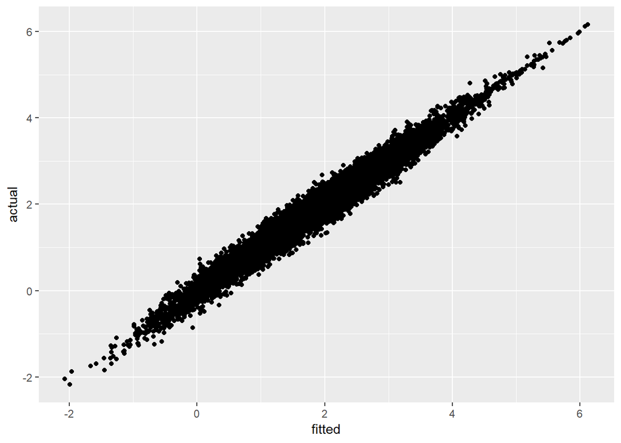

```r
qplot(fitted(pl), df_T_within$y_error, xlab = "fitted", ylab = "actual")
```

4. Check that $β_l$ is not identified with the data without optimization error. Estimate the first stage model of Olley-Pakes with the labor choice without optimization error and report the result.

```r
bw_unidentified <- npplregbw( formula = y ~ l + k + I| k + I, data = df_T_within)
pl_unidentified <- npplreg(bws = bw_unidentified)
```

```r
summary(pl_unidentified)
```

```
##
## Partially Linear Model
## Regression data: 10000 training points, in 5 variable(s)
## With 3 linear parametric regressor(s), 2 nonparametric regressor(s)
##
##                     y(z)
## Bandwidth(s): 0.06925716 0.0188898
##
##                     x(z)
## Bandwidth(s): 0.04754748       0.01892755
##               0.01371559 1208149.52187153
##               1.07611321       0.01884243
##
##                        l        k        I
## Coefficient(s): 1.131465 1.704552 -0.35475
##
## Kernel Regression Estimator: Local-Constant
## Bandwidth Type: Fixed
##
## Residual standard error: 0.1938776
## R-squared: 0.9697083
##
## Continuous Kernel Type: Second-Order Gaussian
## No. Continuous Explanatory Vars.: 2
```

Clearly, $β_l$ is not identified as the estimated value is significantly different from its true value.

5. Estimate the second stage model of Olley-Pakes method. Compute $y_{jt} - \hat{\beta_l} l_{jt}$ and $\hat{\phi}(k_{j, t - 1}, I_{j, t - 1})$ for each `j` and `t` and save it as a data frame naming `df_T_1st`.

```r
beta_l_tilde <- coef(pl)["l_error"]
y_error_tilde <- df_T_within$y -  beta_l_tilde * df_T_within$l


phi_t <- fitted(pl) -  beta_l_tilde * df_T_within$l
phi_t_1 <- c(NA, phi_t[1 : (N*T - 1) ])

df_T_1st = tibble(df_T_within$j, df_T_within$t, y_error_tilde, phi_t_1)


colnames(df_T_1st)[c(1,2)] <- c("j", "t")
```

6. Set the function that computes the GM and name it `moment_OP_2nd`. Show the values of the moments evaluated at the true parameters.

```r
# Add y_error_tilde and phi_t_1 to `df_T_within`
df_T_within <- df_T_within %>%
  dplyr::mutate(y_error_tilde = df_T_1st$y_error_tilde, phi_t_1 = df_T_1st$phi_t_1)

moment_OP_2nd(alpha, beta_0, beta_k, df_T_within)
```

```
##            y            y            y
## -0.007857523 -0.007909354 -0.001520509
```

7. Write a function that returns the value of $Q_{JT}(\alpha, \beta_0, \beta_k)$ and name it `objective_OP_2nd`. Show the value of the objective function evaluated at the true parameters.

```r
objective_OP_2nd <- function(alpha, beta_0, beta_k, df_T_within){
  moment_OP_2nd(alpha, beta_0, beta_k, df_T_within) %*% moment_OP_2nd(alpha, beta_0, beta_k, df_T_within)
}

objective_OP_2nd(alpha, beta_0, beta_k, df_T_within)
```

```
##              [,1]
## [1,] 0.0001266105
```

8. Draw the graphs of the objective function when one of $α$, $β_0$, and $β_k$ are changed from 0 to 1 by 0.1 while the others are set at the true value. Is the objective function minimized at around the true value?

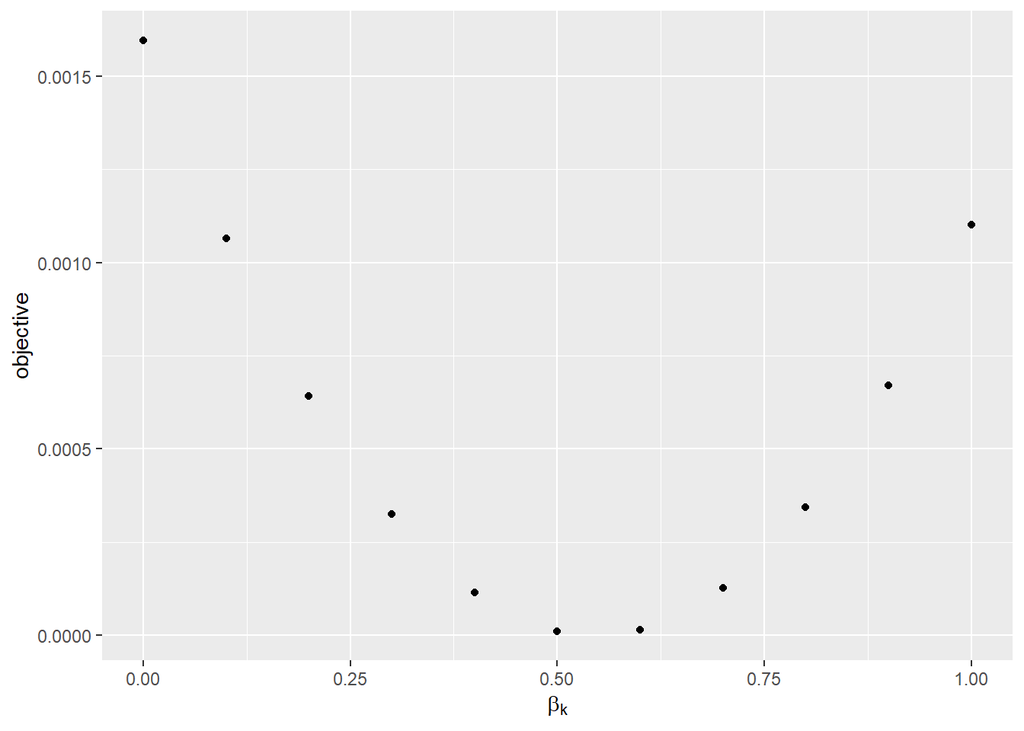

```r
library(latex2exp)
# beta_k
objective = c()
for (val in seq(0, 1, 0.1)){
  objective = c(objective, objective_OP_2nd(alpha, beta_0, val, df_T_within))
}
qplot(seq(0, 1, 0.1), objective, xlab = TeX("$\\beta_k$"))
```

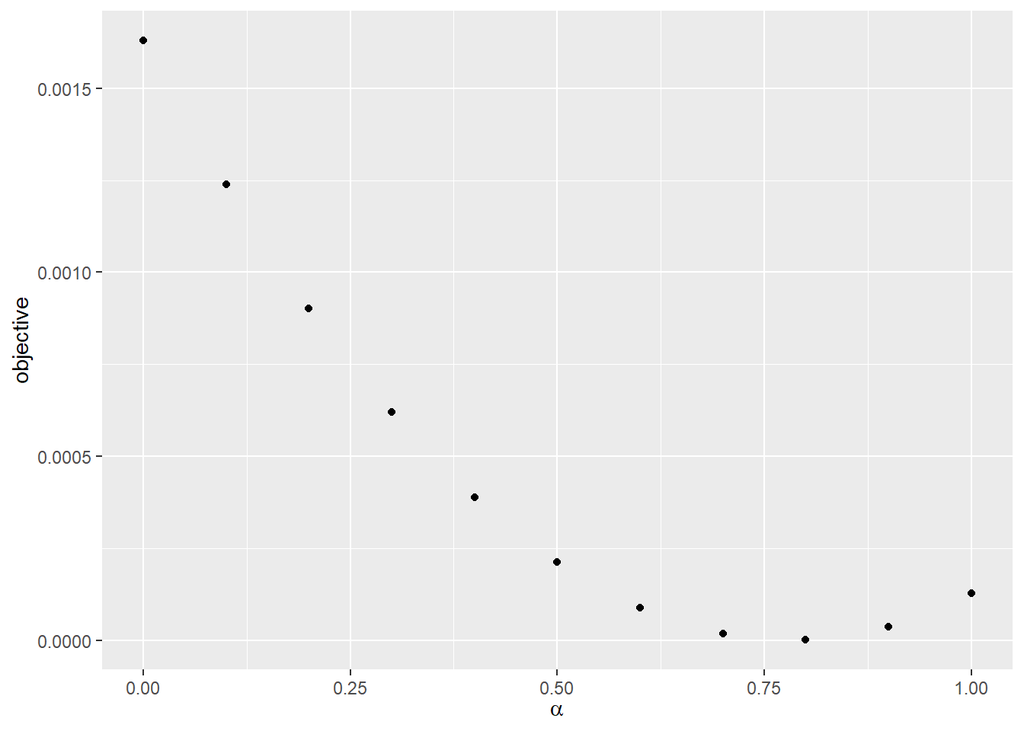

```r
# alpha
objective = c()
for (val in seq(0, 1, 0.1)){
  objective = c(objective, objective_OP_2nd(val, beta_0, beta_k, df_T_within))
}

qplot(seq(0, 1, 0.1), objective, xlab = TeX("$\\alpha$"))
```

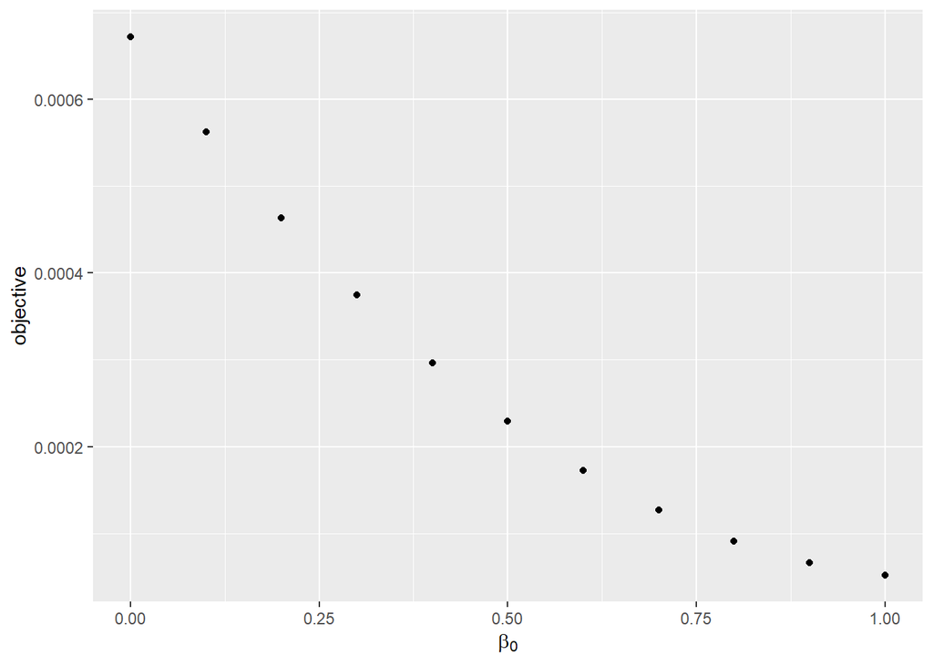

```r
# beta_0
objective = c()
for (val in seq(0, 1, 0.1)){
  objective = c(objective, objective_OP_2nd(alpha, val, beta_k, df_T_within))
}

qplot(seq(0, 1, 0.1), objective, xlab = TeX("$\\beta_0$"))
```

9. Find the parameters that minimize the objective function using `optim`. You may use `L-BFGS-B` method to solve it.

Somehow the results are sensitive to the initial values. Below are different results given two different initials: (0,0,0) and the true ones.

```r
objective_optim <- function(x, df_T_within){
  objective_OP_2nd(x[1], x[2], x[3], df_T_within)
}

optim(par = c(0, 0, 0), fn = objective_optim, gr = NULL, df_T_within = df_T_within,
      method = "L-BFGS-B",
      lower = -1, upper = 1)
```

```
## $par
## [1] 0.7036004 0.7217691 0.7415671
##
## $value
## [1] 0.00000000005998717
##
## $counts
## function gradient
##       30       30
##
## $convergence
## [1] 0
##
## $message
## [1] "CONVERGENCE: REL_REDUCTION_OF_F <= FACTR*EPSMCH"
```

```r
objective_optim <- function(x, df_T_within){
  objective_OP_2nd(x[1], x[2], x[3], df_T_within)
}

optim(par = c(0.7, 1, 0.7), fn = objective_optim, gr = NULL, df_T_within = df_T_within,
      method = "L-BFGS-B",
      lower = -1, upper = 1)
```

```
## $par
## [1] 0.7212354 0.917261 0.6683661
##
## $value
## [1] 0.00000000007817922
##
## $counts
## function gradient
##       11       11
##
## $convergence
## [1] 0
##
## $message
## [1] "CONVERGENCE: REL_REDUCTION_OF_F <= FACTR*EPSMCH"
```